# Assignment Week 10

Sara Leka

2025-05-14

```r
suppressPackageStartupMessages({
  library(GenomicRanges)
  library(epiwraps)
  library(ggplot2)
  library(rGREAT) # Gene Ontology enrichment among genomic regions
})
```

## 1. Download and decompress archive containing bigwig files and peaks (bed) files for three TFs of the CREB family (restricted to chr1 and aligned against the hg38 genome)

```r
options(timeout = 6000)
download.file("https://ethz-ins.org/content/w10.assignment.zip", "w10.assignment.zip")
unzip("w10.assignment.zip")
list.files()
```

## 2. Clustering and visualization to illustrate the relationship between the binding of the different proteins

First, prepare regions and tracks

```r
tracks <- list.files(pattern="bw$")
peaks <- list.files(pattern="bed$")
# we first import the peaks
peaks <- lapply(peaks, rtracklayer::import.bed)
 # we'll focus on the high-quality peaks
peaks <- lapply(peaks, FUN=function(x) x[x$score>800])
# we get the union of non-redundant regions
regions <- reduce(unlist(GRangesList(peaks)))
```

Plotting before clusters

```r
set.seed(123)
ese <- signal2Matrix(tracks, regions, extend=2000)
```

```
## Reading Creb1.bw
```

```
## Reading Creb3.bw
```

```
## Reading Creb3L1.bw
```

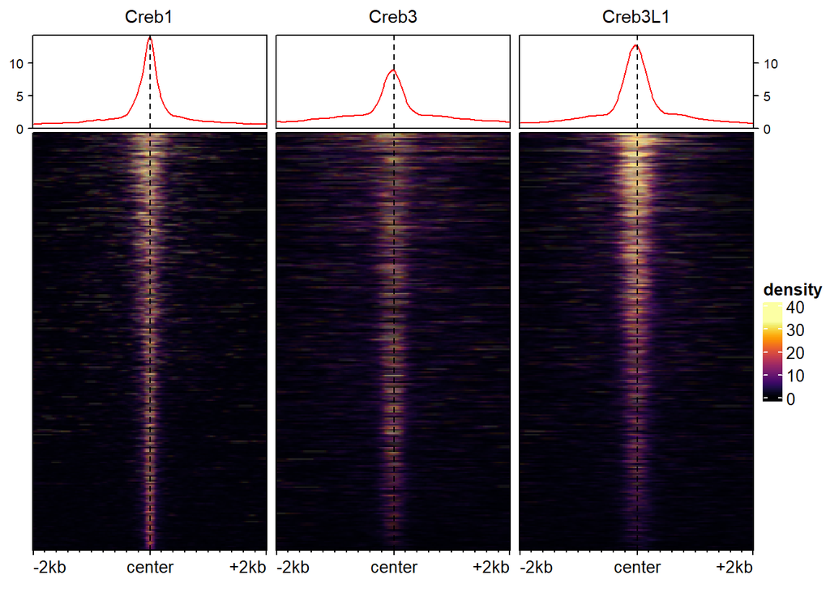

```r
plotEnrichedHeatmaps(ese)
```

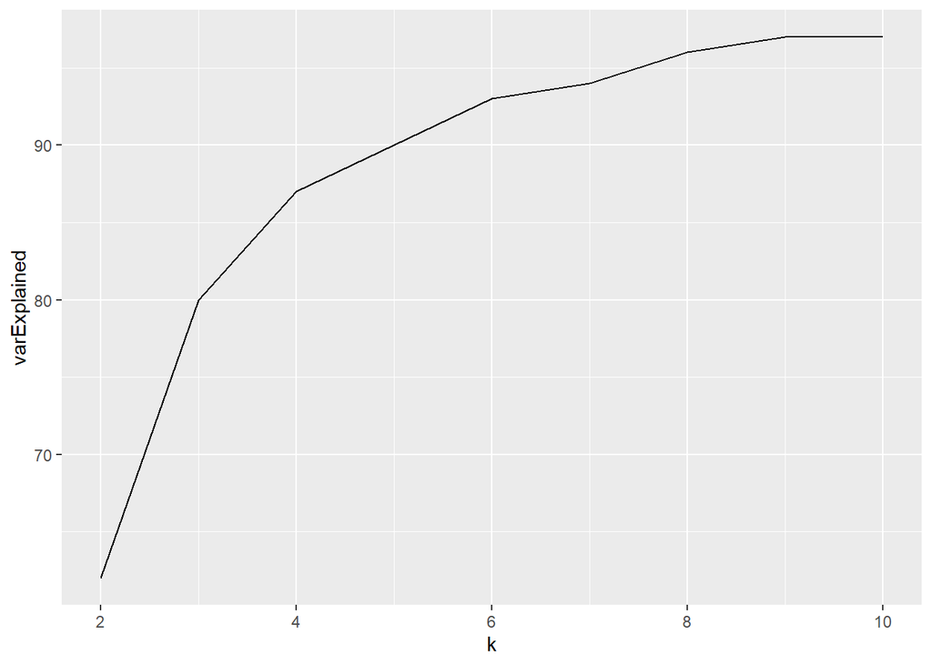

```r
# What k to use?
cl <- clusterSignalMatrices(ese, k=2:10, scaleRows = TRUE)
ggplot(cl$varExplained, aes(k, varExplained)) + geom_line()
```

Clustering

```r
cl <- clusterSignalMatrices(ese, k=4, scaleRows=TRUE)
```

```
##   ~87% of the variance explained by clusters
```

```r
rowData(ese)$cluster <- cl
```

Plot clusters:

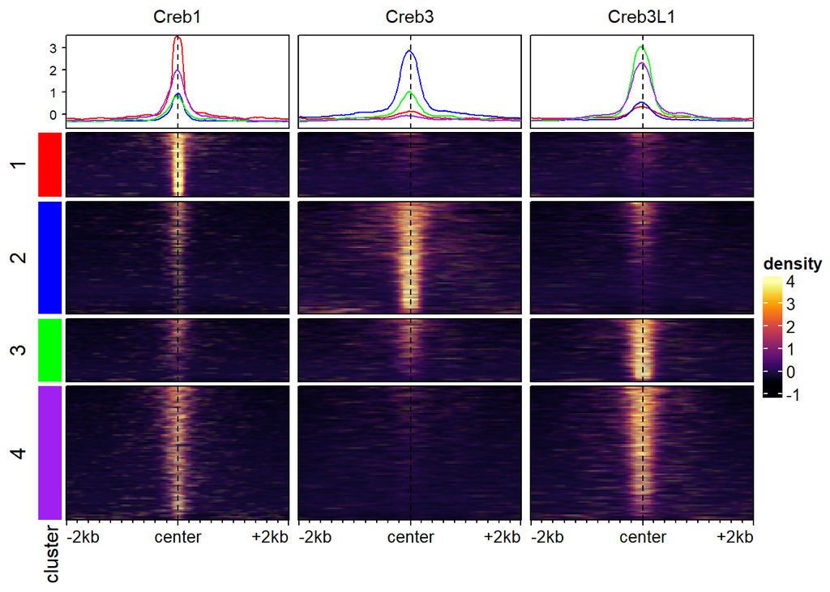

```r
mycolors <- c("1"="red", "2"="blue", "3"="green", "4"="purple")
plotEnrichedHeatmaps(ese, row_split="cluster", mean_color=mycolors, scale_rows = "global")
```

### Result comments

After evaluating the percentage of variance explained by the possible number of clusters, a clustering with k=4 was performed. Cluster 1 (red) shows a strong signal for Creb1 with very weak signal for the other TFs, suggesting a regulation dominated by Creb1. Cluster 2 (blue) on the other hand shows strong peak signal for Creb3 in comparison to the other 2 weak signals in this region. Cluster 3 (green) and cluster 4 (purple) display a strong Creb3L1 signal with noisy weak signal from the other TFs in cluster 3. However, there is a relevant presence form Creb1 in cluster 4 (compared to the absence of Creb3), suggesting potential co-binding of Creb3L1 and Creb1 in this region.

In general there seem to be some overlapping binding preferences (cluster 4 for Creb1 and Creb3L1) and some distinct ones (clearly cluster 1 for Creb1) in the CREB-family transcription factors.

## 3. Enrichment analysis with Gene Ontology and Biological Processes

```r
split_regions <- split(rowRanges(ese), rowData(ese)$cluster)
lengths(split_regions)
```

```
##   1   2   3   4
## 389 684 383 813
```

```r
res <- great(split_regions[["4"]], gene_sets="GO:BP", tss_source="hg38",
             background=regions, cores=2)
```

[output not shown]

[output not shown]

[output not shown]

[output not shown]

```
## * 18110/30830 protein-coding genes left.
```

[output not shown]

[output not shown]

[output not shown]

[output not shown]

[output not shown]

```
## * use GO:BP ontology with 15413 gene sets (source: org.Hs.eg.db).
```

[output not shown]

[output not shown]

[output not shown]

[output not shown]

```
## * in total 813 `gr`.
```

[output not shown]

[output not shown]

[output not shown]

```
## * in total 2480 gene sets.
```

[output not shown]

[output not shown]

```r
bp <- getEnrichmentTables(res)
```

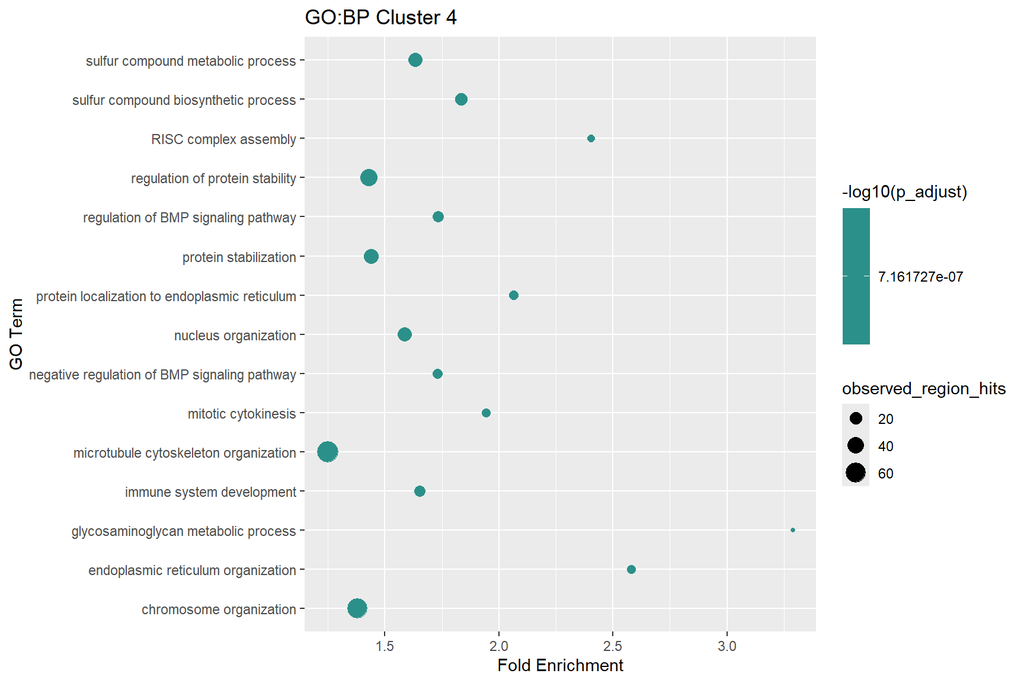

```r
ggplot(head(bp, 15), aes(
  fold_enrichment,
  reorder(description, p_adjust),
  size = observed_region_hits,
  color = -log10(p_adjust)
)) +
  geom_point() +
  scale_color_viridis_c() +
  labs(
    x = "Fold Enrichment",
    y = "GO Term",
    title = "GO:BP Cluster 4"
  )
```